# HW10

*參考書目：A First Course in Statistical Programming with R*

## CH2 Introduction to the R language

### 基礎四則運算

| 符號 | 意義 |
| --- | --- |
| + | 加 |
| - | 減 |
| * | 乘 |
| / | 除 |
| ^ | 次方 |
| %% | 餘數 |
| %/% | 整除部分 |

### 控制一行長度

例：

```r
options(width=40)
1:20
```

```
##  [1]  1  2  3  4  5  6  7  8  9 10 11 12
## [13] 13 14 15 16 17 18 19 20
```

### 尋求說明

在欲了解之功能前加上**?**或者將其加在**help()**之括弧處即可

### 結束R程式

```
q()
```

### 命名並儲存值

```
=
<-
```

### 查看目前所存物件

```
ls()
object()
```

### 移除所存物件

括弧中放入欲移除之物件

```
rm()
```

### 向量

```
c()
```

例：

```r
c(0,10,20)
```

```
## [1]  0 10 20
```

### 數列

- seq()
  - seq(a,b,by=t)

| 變數 | 意義 |
| --- | --- |
| a | 開始之數字 |
| b | 結束之數字 |
| t | 公差 |

- rep()
  - rep(c,x)

| 變數 | 意義 |
| --- | --- |
| c | 常數 |
| x | 重複之次數 |

- 例：

```r
seq(11,30,by=3)
```

```
## [1] 11 14 17 20 23 26 29
```

```r
rep(10,5)
```

```
## [1] 10 10 10 10 10
```

### 矩陣

- matrix()
  - matrix(data, nrow, ncol, byrow)

| 變數 | 意義 |
| --- | --- |
| data | 組成矩陣之數字 |
| nrow | row的數量 |
| ncol | column的數量 |
| byrow | 系統原先預設排列方式為填滿一個column之後再排下一個，透過此項設定 T/F 可控制先填滿 row/column |

- 例：

```r
matrix(20:39,nrow=2,ncol=10,byrow=F)
```

```
##      [,1] [,2] [,3] [,4] [,5] [,6] [,7]
## [1,]   20   22   24   26   28   30   32
## [2,]   21   23   25   27   29   31   33
##      [,8] [,9] [,10]
## [1,]   34   36    38
## [2,]   35   37    39
```

```r
matrix(20:39,nrow=2,ncol=10,byrow=T)
```

```
##      [,1] [,2] [,3] [,4] [,5] [,6] [,7]
## [1,]   20   21   22   23   24   25   26
## [2,]   30   31   32   33   34   35   36
##      [,8] [,9] [,10]
## [1,]   27   28    29
## [2,]   37   38    39
```

## CH3 Programming statistical graphics

### High-level plots

#### 可用圖形

```
barplot()
dotchart
pie()
hist()
boxplot()
plot()
qqplot()
```

#### 範例

*圖形之繪製方式皆大同小異，如想知道更詳細可用* **help()** *獲得資訊* *以下以R內建資料VADeaths為例，繪製barplot及dotchart*

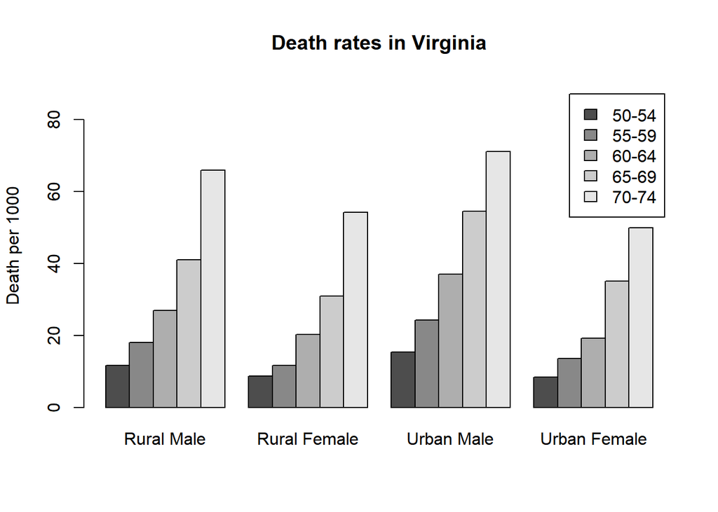

```r
barplot(VADeaths, beside=TRUE, legend=TRUE, ylim=c(0,90),
 ylab="Death per 1000",
 main="Death rates in Virginia")
```

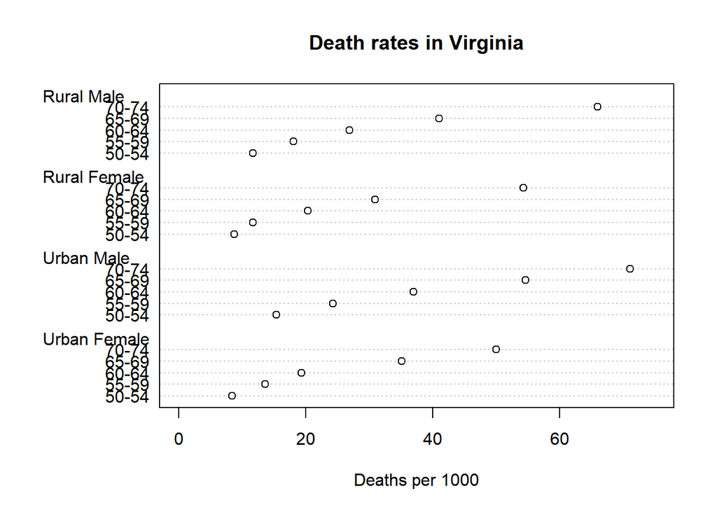

```r
dotchart(VADeaths,xlim=c(0,75),
 xlab="Deaths per 1000",
 main="Death rates in Virginia")
```

### Low-level graphics functions

- par()
  - 建立繪圖區，可設定與邊界之距離
- plot()
  - plot(x,y,xlab,ylab,type)
  - 另可用**curve()**增加線條於圖上

| 變數 | 意義 |
| --- | --- |
| x | x軸資料 |
| y | y軸資料 |
| xlab | x軸命名 |
| ylab | y軸命名 |
| type | 圖形之顯示，因較為複雜故列於下表 |

| type代號 | 顯示 |
| --- | --- |
| “p” | points |
| “l” | lines |
| “b” | both |
| “c” | the lines part alone of “b” |
| “o” | both ‘overplotted’ |
| “h” | ‘histogram’ like (or ‘high-density’) vertical lines |
| “s” | stair steps |
| “S” | other steps, see ‘Details’ below |
| “n” | no plotting. |

- text()
  - 選定x,y座標，並寫入標題名稱
- points()
  - 選定x,y座標

#### 範例：

下列使用上述函式，並標註部分系統預設(如邊界順序等)

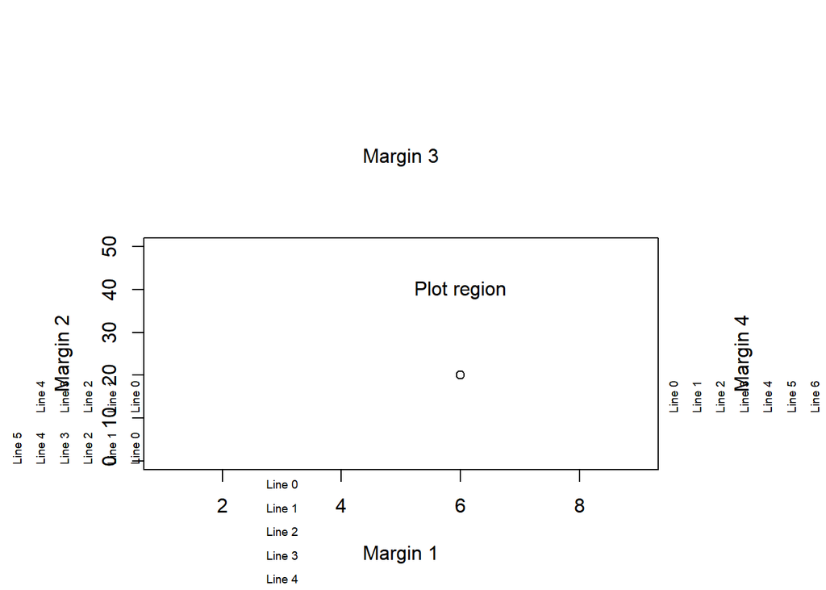

```r
par(mar=c(5,6,10,7)+0.1)
plot(c(1,9),c(0,50),type="n",xlab="",ylab="")

text(6,40,"Plot region")
points(6,20)
mtext(paste("Margin",1:4),side=1:4,line=3)
mtext(paste("Line",0:4),side=1,line=0:4,at=3,cex=0.6)
mtext(paste("Line",0:4),side=2,line=0:4,at=15,cex=0.6)
mtext(paste("Line",0:10),side=2,line=0:10,at=3,cex=0.6)
mtext(paste("Line",0:7),side=4,line=0:7,at=15,cex=0.6)
```

## CH4 Programming with R

### 函式

- function(){}
  - 此函式可用於定義某些不內建於系統，但可能需要多次使用的式子
  - 可在小括號中列出需輸入之變數
  - 大括號中則定義此自訂函數所做運算
  - 以**return()**控制回傳之數據
- for(){}
- 小括號中放入範圍(如 i<10 等)
- 大括號中放入須執行之動作
- if(){}
- 小括號中放入條件
- 大括號中放入符合條件時須執行之動作
- 若不符合條件者須執行其他動作，則搭配使用**else{}**

#### 範例

```r
Eratosthenes <- function(n) {
  #Return all prime numbers up to n (based on the sieve of Eratosthenes)
  if (n >=2) {
    sieve <- seq(2,n)
    primes <- c()
    for (i in seq(2,n)) {
      if (any(sieve==i)) {
        primes <- c(primes,i)
        sieve <- c(sieve[(sieve%%i)!=0],i)
      }
    }
    return(primes)
  } else {
      stop("Input value of n should be at least 2.")
  }
}
```

## CH5 Simulation

### random variables

```
runif()
rbinom()
rpois()
rnorm()
rexp()
```

- 透過**set.seed()**的方式，可使每次隨機取出之數字相同
- sample(x,size,replace)

| 變數 | 意義 |
| --- | --- |
| x | 欲隨即抽樣之範圍 |
| size | 取出之樣本數 |
| replace | 是否取出放回 |

## CH6 Computational linear algebra

### 矩陣

- matrix()
  - 詳見CH2
- cbind()
  - 括號放入向量

### 呼叫矩陣之部分

假設今有一矩陣X

- X[a,b]
  - 若其中一個未放置數字，則會出現一整行/列

| 符號 | 意義 |
| --- | --- |
| a | row |
| b | column |

#### 範例

```r
X= matrix(c(1,2,3,1,4,9),ncol=2)

X[,2]
```

```
## [1] 1 4 9
```

```r
X[,2,drop=F]
```

```
##      [,1]
## [1,]    1
## [2,]    4
## [3,]    9
```

- rownames()、colnames()
  - 為row、column 命名
- diag()
  - 列出矩陣之對角線數值
- %*%
  - 用於矩陣相乘
- t()
  - 轉置矩陣
- solve()
  - 若直接放一個矩陣，可得其反矩陣
  - 若Ax=x,則x=solve(A,b)

## CH7 Numerical optimization

### The golden section

#### 範例

```r
f <- function(x) {
  abs(x - 3.5) + abs(x - 2) + abs(x - 1)
}

golden <- function (f, a, b, tol = 0.0000001) {
  ratio <- 2 / (sqrt(5) + 1)
  x1 <- b - ratio * (b - a)
  x2 <- a + ratio * (b - a)
  f1 <- f(x1)
  f2 <- f(x2)
  while(abs(b - a) > tol) {
    if (f2 > f1) {
      b <- x2
      x2 <- x1
      f2 <- f1
      x1 <- b - ratio * (b - a)
      f1 <- f(x1)
    } else {
      a <- x1
      x1 <- x2
      f1 <- f2
      x2 <- a + ratio * (b - a)
      f2 <- f(x2)
    }
  }
  return((a + b) / 2)
}
```

### 使用已存在之packages

- 先找尋所需package之名稱，再將其依序放入下列兩個括號
  - install.packages()
  - library()